# STAT 240

Introduction to Data Science: Week 1

Owen G. Ward

## This week

- What is data science?
- What is this course about?
- Logistics
- A recap/introduction on R programming

# What is Data Science

## Data

> Related items of (chiefly numerical) information considered collectively, typically obtained by scientific work and used for reference, analysis, or calculation.

—OED

## Science

> A branch of study that deals with a connected body of demonstrated truths or with observed facts systematically classified and more or less comprehended by general laws, and incorporating trustworthy methods for the discovery of new truth in its own domain.

—OED

## So what is Data Science?

> An interdisciplinary science concerned with the analysis and extraction of information from large sets of data, typically combining elements of statistics, maths, computing, and other subjects.

—OED

- See [this article](https://hbr.org/2012/10/data-scientist-the-sexiest-job-of-the-21st-century) from the Harvard Business review (2012)
- In practice, data science consists of:
- A question of interest
  - Scientific
  - Business
- Figuring out how to go about answering this question
  - What data do you need?
  - What statistical tool will you use to analyse this data?
- How will you communicate the results to key stakeholders?

## Example: Spotify Wrapped

- Want something that people will enjoy sharing
- Write a script to get some simple summary statistics about listening
- Present them in an interesting way
- Trying to encourage people to use/share that they use Spotify

[figure not shown]

Spotify Wrapped

## Disease Prediction

- [Early detection of viruses using wastewater](https://www.ft.com/content/b49882ec-e74c-4297-8a8d-9b149b6c0adf)
- Figure out how to track presence of patogens in wastewater, predict disease outbreaks early

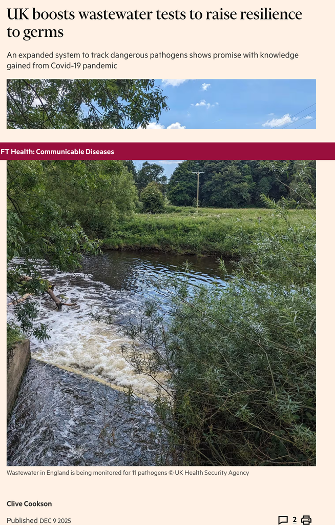

FT Article

## Going for it on 4th down (NFL)

- [Analytics has changed the NFL and other sports](https://www.nytimes.com/athletic/4699367/2023/07/28/nfl-advanced-analytics-data/)
- Every team has multiple data scientists, informing in game decisions
- Winners of the [Big Data bowl](https://operations.nfl.com/gameday/analytics/big-data-bowl/) regularly get jobs (SFU teams have won before)

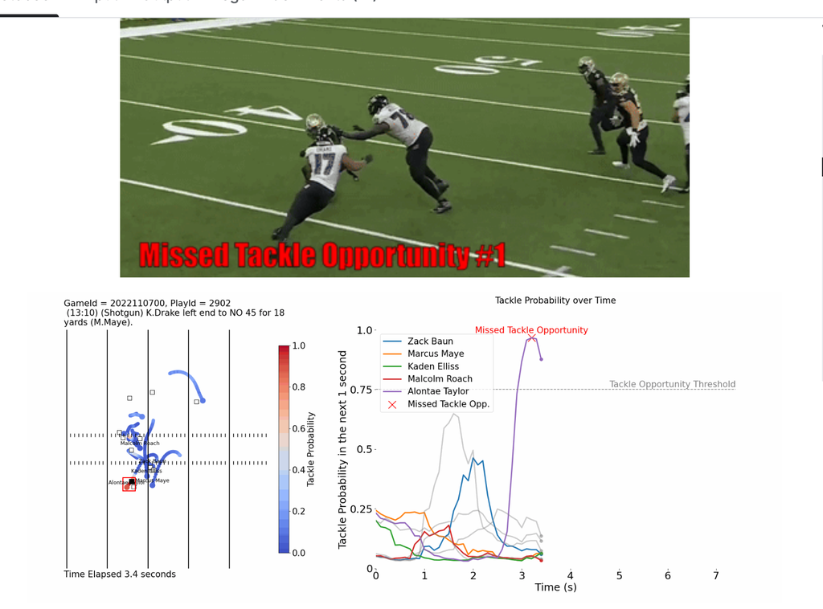

Big Data Bowl Winner, 2024

## AI Tools (Very briefly)

- LLMs take in a query, convert that text into a numerical representation and then leverage massive amounts of data to produce a “good” response
- They depend on advanced data science methods to perform these tasks, do them quickly
- Data science drives a huge amount of scientific discovery

# What is this course about?

## Overall objectives

- The aim of this course is to provide you with some of the key skills required to solve some “typical” data science problems
- There are lots of other problems that aren’t typical, so you will pick up skills that you’ll use in the future
- Different examples each week, with different methods, different problems in collecting/tidying data

## Key Skills

- Reading in data, in multiple different formats
- Scraping data from websites, API’s
- Using common data science methods:
  - Regression
  - Classification (these first two are prediction tools)
  - Clustering

## Accessing Data

- Will use SQL to extract data from large datasets
- Will see how to query an API for a specific problem
- Will see some techniques to extract information from text data
- Just a brief introduction to the basics to get you started!

# Logistics

## Class and Labs

- Class every Wednesday, 1.30-2.20pm in AQ3181
- Class every Friday 11.30-12.20pm in BLU9660
- Weekly labs starting Friday Jan 16th, all in BLU9402
- You must attend the lab you are signed up for

## You

- Have taken a previous stats course (STAT 201/203/270) and a previous computing course (CMPT 120/125)
- Stat 260 is **recommended** but not required
  - You may find coding in R significantly easier if you’ve taken 260, but will do some things differently
  - If you have experience with Python the differences are relatively minor and I’ll try to highlight a lot of them in the first few weeks

## Course Materials

- The course materials (slides, labs) should be almost comprehensive
- Previously 2 textbooks recommended, largely optional
  - Munzert et al, 2014, Automated Data Collection with R get it here.
  - Cotton, 2013 Learning R get it here.
- There may be some reading from the first, second useful if little R experience
- [This](https://rstudio-education.github.io/hopr/) another good intro to R

## Assessment

- Weekly lab assignments 15%
- Weekly lab attendance 5%
- In class midterm coding exam 20%
  - Friday 27th February (no lab this day)
- Take home final coding exam 20%
  - Friday April 10th (no lab this day)
- Written final exam (2hrs) 40%
  - In regular exam period (likely middle 2 hours)

## Weekly Labs

- 10 Labs total (excluding exams), lowest score dropped
- You need to bring your own laptop to complete the lab
  - If this an issue please let me know ASAP
- First lab (Lab0) just basic setup, installing R and RStudio
- Will work on a weekly problem set, with the TA available for questions during the lab
- Problem set due at the end of the following Tuesday,
- Late penalty will be 10% per hour late, after that 0.
- Attendance expected and will be recorded (you must attend the entire lab, otherwise the TA will give you 0!)

## Exams

- Exams may cover any material from slides, lectures, labs and required readings and will be cumulative
- See the SFU academic integrity policy [here](https://www.sfu.ca/students/academicintegrity/what-is-it.html) which will be strictly adhered to
- I will give you clear guidelines before the exams, **which must be followed**

## The use of AI

- LLM’s can be a useful tool when programming, can help with tasks like debugging
- However, they cannot replace you understanding how to program
  - If they did, you wouldn’t be able to find a job!
- Need to learn how to use them efficiently but cannot rely on them
- Be wary of using them, they can give wrong results
  - If you’re not familiar with R, they can do more harm than good
- Later in the semester we may discuss how to use them responsibly and efficiently
- **Not allowed for any coursework or exam** but can be used as part of your study!

## Getting Help

- The TA will have weekly office hours, time TBC
- I will have weekly office hours, time TBC, starting next week
- The weekly lab a place to work with peers, get feedback from the TA also
- Will have a weekly discussion post on canvas for questions, will check daily
- Email me (oward@sfu.ca) only for questions which cannot be asked there

# Programming in R

## A working example

- For the rest of this class we’ll go through a (simple) working example, describing the code used, as an introduction/recap to R
- Focus is different to stat 260, not as much on specific coding tools/functions but rather on how we can use code to understand data in general, answer data science questions

## Example: Basketball hot hand

- Data science is about pulling together data to answer questions, provide insights, or make decisions. Here’s an example:
- The *hot hand* is a phenomenon (existing or not) by which a successful outcome increases the chance of further successful outcomes
- The term originates from basketball. We’ll examine historical data from the NBA (National Basketball Association) for evidence of the hot hand

## Basketball hot hand

- We need what’s referred to in basketball as a *shot log*: A breakdown of every shot at net

```r
# Data from https://www.kaggle.com/datasets/dansbecker/ ...
#    nba-shot-logs
# "Data on shots taken during the 2014-2015 season ...
#   Scraped from NBA's REST API."

data <- read.csv("shot_logs.csv")
```

- A `.csv` file is a table of data in plain text (values separated by commas). With the headers, this file should be self explanatory if you import into excel

## Basketball hot hand

- We’ll check if a player was more likely to make a shot if their immediately previous shot was made (here, a shot is “made” if it is successful and “missed” otherwise)
- Our aim is to get this contingency table:

|  | MADE | MISSED |
| --- | --- | --- |
| HOT | W | X |
| NOT | Y | Z |

|  | MADE | MISSED |
| --- | --- | --- |
| HOT | W | X |
| NOT | Y | Z |

- `HOT` counts shots by players for which their immediately previously shot was made. `NOT` counts shots by players for which their immediately previous shot was not made

## Example: Basketball hot hand

- We’ll write code to get `W`, `X`, `Y` and `Z` out of `shot_logs.csv`. Note that the data in `shot_logs.csv` aren’t sorted, so we’ll start by sorting:

```r
data <- data[order(
  data$player_name, data$GAME_ID,
  data$PERIOD, data$SHOT_NUMBER
), ]
```

- Now, our data are sorted by player. The rows for each player are sorted by game, and then by shot number from the start to the end of the game (note that in the *csv* shot numbers are given for each period in the data)
- With this organization, we can tell if a shot is in the `HOT` row or the `NOT` row in the contingency table by looking at the immediately preceding row in the data frame
- Next, we’ll loop through each shot and see if it’s a `W`, `X`, `Y` or `Z`, and increment the corresponding variable (starting the count of each variable at 0):

## Example: Basketball hot hand

```r
W <- 0
X <- 0
Y <- 0
Z <- 0
for (i in 2:dim(data)[1]) {
  if (data$SHOT_RESULT[i - 1] == "made") { # HOT
    if (data$SHOT_RESULT[i] == "made") {
      W <- W + 1
    } else {
      X <- X + 1
    }
  } else { # NOT
    if (data$SHOT_RESULT[i] == "made") {
      Y <- Y + 1
    } else {
      Z <- Z + 1
    }
  }
}
result <- data.frame(MADE = c(W, Y), MISSED = c(X, Z))
```

## Example: Basketball hot hand

- Here’s the result:

|  | MADE | MISSED |
| --- | --- | --- |
| HOT | 25962 | 31942 |
| NOT | 31942 | 38222 |

```
Scoring percent after making a shot: 44.8%
```

```
Scoring percent after missing a shot: 45.5%
```

## **Discussion**: Basketball hot hand

- Is this evidence against the hot hand?
- What assumptions have we made? Are they valid?
- How would we improve this analysis?
- Did we make any mistakes? Cut any corners?
- Professional sports teams have data analysts on their staff and contracted. The NFL (National Football League) runs a yearly [Big Data Bowl](https://operations.nfl.com/gameday/analytics/big-data-bowl/)
- There is more recent discussion on the hot hand, such as [here](https://statmodeling.stat.columbia.edu/2018/12/14/couple-thoughts-regarding-hot-hand-fallacy-argument/)

## R review

- The rest of these slides review R by breaking down the above code
- R is an interpreted language. An R script is run line by line

```r
# Data from https://www.kaggle.com/datasets/dansbecker/ ...
#    nba-shot-logs ...
```

- Lines starting with `#`s are comments and are ignored

## R review

```r
data <- read.csv("shot_logs.csv")
```

- Here, `read.csv` is a function. Functions take arguments (a comma separated list inside round parentheses), and return values
- In this line of code, the argument is the path to a file, and the returned value is a data frame representing the table in the file

## R review

```r
data <- read.csv("shot_logs.csv")
```

- `data` is a variable, which gets assigned to the data frame returned by `read.csv`. Data frames are two dimensional objects. In this case, the rows are numbered and the columns are named
- Values can be accessed with square parentheses. So, to get the `player_name` indicated by the 1729th record of the file, we’d use:

`data$player_name[1729]` or `data[1729, "player_name"]`

## R review

```r
data <- data[order(data$player_name, data$GAME_ID,
                   data$PERIOD, data$SHOT_NUMBER), ]
```

- Each row (record) of the variable `data` is information about a shot at the basket. Given a specific shot, we want to know about the immediately previous shot that player attempted

```r
data <- data[order(data$player_name, data$GAME_ID,
                   data$PERIOD, data$SHOT_NUMBER), ]
```

- We can do this easily by arranging `data` so that all shots by a single player are arranged in a contiguous block of rows. We do this by sorting. The R function `order` when used as an index into the rows of a data frame and passed rows of the data frame will rearrange according to the sorted order of the first argument (with ties broken by subsequent arguments)
- The column index for `data` is not provided. That means all columns will be returned. The new sorted data frame is made, and then the value of `data` is overwritten by the sorted result

## R review

```r
W <- 0
X <- 0
Y <- 0
Z <- 0
for (i in 2:dim(data)[1]) {
  ...
```

- We want to populate the cells of the contingency table:

|  | MADE | MISSED |
| --- | --- | --- |
| HOT | W | X |
| NOT | Y | Z |

- By definition, each shot will be in one of these cells. (**Discussion**: Really? What about the first shot of the first game of the first player?) So, we initialize each cell to be zero, and then loop through each shot

## R review

```r
for (i in VECTOR) {
  ... # body
}
```

- In this code, the ellipsis labelled body is executed once for each element of the variable `VECTOR`. Each execution has the variable `i` set to the corresponding element of `VECTOR`.

Example:

```r
for (i in c(2, 3, 5)) {
  print(i)
}
```

```
[1] 2
[1] 3
[1] 5
```

- Vectors are sequences of elements. In R, vectors can be created using the confusing notation `c(v1, v2, ... )` (here `v1`, `v2`, … are the desired elements)

## R review

```r
for (i in 2:dim(data)[1]) {
  if (data$SHOT_RESULT[i - 1] == "made") { # HOT
    ...
  } else { # NOT
    ...
  }
}
```

```r
for (i in 2:dim(data)[1]) {
  if (data$SHOT_RESULT[i - 1] == "made") { # HOT
    ...
  } else { # NOT
    ...
  }
}
```

- The body of our loop does some additional control flow. When we see `if(a) { ... } else { ... }` the first ellipsis is executed if `a` is true. Otherwise the second ellipsis is executed

## R review

```r
...
  if (data$SHOT_RESULT[i - 1] == "made") { # HOT
    ...
  } else { # NOT
    ...
  }
...
```

- Consider a given record `i` of `data` (the `i`-th shot; the `i`-th row). By definition of the contingency table, and by the sorting of the data frame, this shot contributes to the `HOT` row of the contingency table if and only if the immediately preceding row is a successful (“made”) shot (**Discussion**: Really? What if `i` is the first shot of game $j$ with $j>2$?)
- We check if the immediately preceding row is a successful (“made”) shot. If so, we know we have to increment one of the `HOT` cells: `W` or `X`. Otherwise, we’ll increment `Y` or `Z`

```r
...
  if (data$SHOT_RESULT[i - 1] == "made") { # HOT
    if (data$SHOT_RESULT[i] == "made") {
      W = W + 1
    } else {
      X = X + 1
    }
  } ...
```

- If the condition of the first if statement here is true, the previous shot was “made”. So, we’re here in the contingency table:

|  | MADE | MISSED |
| --- | --- | --- |
| HOT | W | X |

- Then, if *this* shot was “made” also, we know we are here:

|  | MADE |
| --- | --- |
| HOT | W |

- Otherwise, we’re *here* (as follows). We increment accordingly:

|  | MISSED |
| --- | --- |
| HOT | X |

## R review

- The same logic applies for the *else* clause of the outer *if* statement of the body:

```r
...
  } else { # NOT
    if (data$SHOT_RESULT[i] == "made") {
      Y = Y + 1
    } else {
      Z = Z + 1
    }
  }
...
```

- After the for loop is done, the cells are correct so we make the contingency table and store it in the variable `result`:

```r
result <- data.frame(MADE = c(W, Y), MISSED = c(X, Z))
```

```r
data.frame(
  V1 = c(x1, x2, ...), V2 = c(y1, y2, ...),
  V3 = c(z1, z2, ...)
)
```

- The above code makes a new data frame. The columns of the data frame are named “V1”, “V2”, “V3” and the first row is given by the vector `x1`, `y1`, `z1` and the second row is given by the vector `x2`, `y2`, `z2` and so on.

For example, the following code:

```r
data.frame(
  V1 = c(2, 3, 5, 7), V2 = c(11, 13, 17, 19),
  V3 = c(23, 29, 31, 37)
)
```

produces this data frame:

| V1 | V2 | V3 |
| --- | --- | --- |
| 2 | 11 | 23 |
| 3 | 13 | 29 |
| 5 | 17 | 31 |
| 7 | 19 | 37 |

## R review

- So, with this line:

```r
result <- data.frame(MADE = c(W, Y), MISSED = c(X, Z))
```

the contingency table we’re making to explore the hot hand is done.

- Next, we compute the percent of the time historically that anyone had a successful attempt, given that their previous attempt was successful. And compare it to the percent of the time historically that anyone had a successful attempt, given that their previous attempt was unsuccessful.
- **Discussion**: Again, this isn’t perfect. What corner have we cut? And what is the maximum error this will introduce?

## R review

- We use the functions `cat` and `sprintf` to make the output rounded and nice looking:

```r
cat(sprintf(
  "Scoring percent after making a shot: %.1f%%\n",
  100 * W / (W + X)
))

cat(sprintf(
  "Scoring percent after missing a shot: %.1f%%\n",
  100 * Y / (Y + Z)
))
```

- [`sprintf`](https://stat.ethz.ch/R-manual/R-devel/library/base/html/sprintf.html) is an old style of function that allows complete control over how elements are printed

## (Optional) Reading

- Munzert: Preface
- Optional: Cotton Chapters 1 & 2 (read this if you need more resources for learning R)
- [Hands on Programming with R](https://rstudio-education.github.io/hopr/) is also a good introduction if you want some more reading on the basics

## Next Week

- Labs begin next Friday (Jan 16th)
- Get R/RStudio installed if you haven’t done this. Instructions on Canvas
- Post on the canvas discussion if you have any questions!
- Spend time going through the code from class, the best way to learn is by doing it yourself